# Getting Familiar with `ggplot2`

# **G**rammar of **G**raphics with **`gg`**`plot2`

[figure not shown]

# Data Visualization

We will learn how to visualize data using the **`ggplot2`** package: one of the most elegant and most versatile systems for creating graphs.

`ggplot2` implements the **grammar of graphics**, a coherent system for describing and building graphs.

> - Do cars with big engines use more fuel than cars with small engines?
> - What does the relationship between engine size and fuel efficiency look like?
> - Is it positive? Negative? Linear? Nonlinear?

# `mpg` dataset

A **data frame** is a rectangular collection of variables (in the columns) and observations (in the rows). `mpg` contains observations collected by the US Environment Protection Agency on 38 models of car.

```r
library(tidyverse)
```

Print the `mpg` dataframe:

```r
print(mpg)
```

| manufacturer | model | displ | year | cyl | trans | drv | cty | hwy | fl | class |
| --- | --- | --- | --- | --- | --- | --- | --- | --- | --- | --- |
| audi | a4 | 1.8 | 1999 | 4 | auto(l5) | f | 18 | 29 | p | compact |
| audi | a4 | 1.8 | 1999 | 4 | manual(m5) | f | 21 | 29 | p | compact |
| audi | a4 | 2.0 | 2008 | 4 | manual(m6) | f | 20 | 31 | p | compact |
| audi | a4 | 2.0 | 2008 | 4 | auto(av) | f | 21 | 30 | p | compact |
| audi | a4 | 2.8 | 1999 | 6 | auto(l5) | f | 16 | 26 | p | compact |
| audi | a4 | 2.8 | 1999 | 6 | manual(m5) | f | 18 | 26 | p | compact |
| audi | a4 | 3.1 | 2008 | 6 | auto(av) | f | 18 | 27 | p | compact |
| audi | a4 quattro | 1.8 | 1999 | 4 | manual(m5) | 4 | 18 | 26 | p | compact |
| audi | a4 quattro | 1.8 | 1999 | 4 | auto(l5) | 4 | 16 | 25 | p | compact |
| audi | a4 quattro | 2.0 | 2008 | 4 | manual(m6) | 4 | 20 | 28 | p | compact |

[output cut: 224 more lines]

# Relationship of `displ` and `hwy`

Among the variables in `mpg` are:

- `displ`, a car’s engine size, in liters.
- `hwy`, a car’s fuel efficiency on the highway, in miles per gallon (mpg).

A car with a low fuel efficiency consumes more fuel than a car with a high fuel efficiency when they travel the same distance.

# A first plot

A car with a low fuel efficiency consumes more fuel than a car with a high fuel efficiency when they travel the same distance.

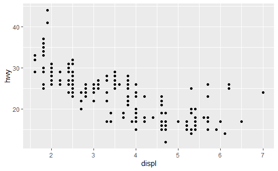

```r
ggplot(data = mpg) +
  geom_point(mapping = aes(x = displ,
                           y = hwy))
```

The plot shows a *negative relationship* between engine size (`displ`) and fuel efficiency (`hwy`). In other words, cars with big engines use more fuel.

# Deconstructing the plot

With `ggplot2`, you begin a plot with the function `ggplot()`.

- `ggplot()` creates a *coordinate system* that you can add *layers* to.
- The first argument of `ggplot()` is the *dataset* to use in the graph. So `ggplot(data = mpg)` creates an empty graph.
- You complete your graph by adding one or more *layers* to `ggplot()`. The function `geom_point()` adds a layer of points to your plot, which creates a **scatterplot**.

# Mapping data to aesthetics

> An **aesthetic** is a visual property of the objects in your plot. Aesthetics include things like the size, the shape, or the color of your points. You can display a point in different ways by changing the values of its aesthetic properties.

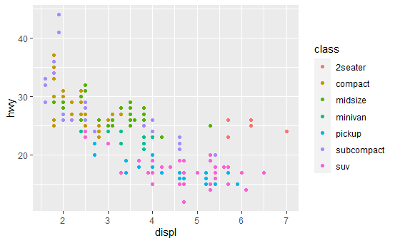

```r
ggplot(data = mpg) +
  geom_point(mapping = aes(x = displ,
                           y = hwy,
                           color = class))
```